# Final Project 2026 — Yacht Hydrodynamic Resistance

## IMPORTANT:

read carefully the instruction for the final project in the pdf file

**Project2026_INFO.pdf**

## Yacht hydrodynamic resistance

**Source.** UCI Machine Learning Repository, https://archive.ics.uci.edu/dataset/243/yacht+hydrodynamics. Original record: Gerritsma, Onnink and Versluis, *Geometry, resistance and stability of the Delft Systematic Yacht Hull Series*, 1981.

**Data.** The dataset describes 22 different hull forms (sailing yacht), each tested at multiple Froude numbers in a towing tank, producing 308 hull-form $\times$ Froude-number rows.

Variables:

`LCB` : longitudinal position of the center of buoyancy (% length).

`prismatic` : prismatic coefficient (dimensionless).

`L_disp` : length-displacement ratio.

`beam_draught` : beam-draught ratio.

`L_beam` : length-beam ratio.

`Froude` : Froude number (dimensionless, $Fn = v/\sqrt{gL}$), in [0.125, 0.45]. The dominant predictor.

`resistance` : residuary resistance per unit weight of displacement (target variable).

**Task.** The physics of the problem says that for sailing yachts the residuary resistance follows a power law of the Froude number with exponent close to 4 in the bulk regime. A good Bayesian project explores this:

1. **Log-log regression.** Fit
   $$\log(\mathrm{resistance}) = \beta_0 +
   \beta_F\,\log(\mathrm{Froude}) + \sum_k \beta_k\,\mathrm{hull}_k +
   \varepsilon\,.$$
   Verify that $\hat\beta_F \approx 4$.
2. **BAS / BMA.** Use `bas.lm` to enumerate the $2^5$ submodels over the five hull-geometry covariates and identify which of them (LCB, prismatic, L/disp, B/draught, L/beam) carry signal once `Froude` is in the model.
3. **Correct for heteroscedasticity.** Train the nonlinear model
   $$\mathrm{resistance} =
   k\,\mathrm{Froude}^{\gamma_F}\,\exp\left\{\sum_k
   \beta_k\,\mathrm{hull}_k \right\} + \varepsilon$$
   where only the form factors that appear relevant in the model selection phase are kept for the nonlinear modelling. Compare the results with the log-log regression and discuss the impact of the heteroscedasticity correction on the inference on $\gamma_F$ and on the hull-geometry covariates.
4. Plot the posterior predictive curves and compare the curves with or without the treatment of the heteroscedasticity and compare the curves with the data.

```r
rm(list=ls())
# Yacht hydrodynamics — UCI #243
yh = read.csv("data/yacht_hydro.csv")
dim(yh)
```

```
## [1] 308   7
```

```r
head(yh)
```

|  | LCB | prismatic | L_disp | beam_draught | L_beam | Froude | resistance |
| --- | --- | --- | --- | --- | --- | --- | --- |
| 1 | -2.3 | 0.568 | 4.78 | 3.99 | 3.17 | 0.125 | 0.11 |
| 2 | -2.3 | 0.568 | 4.78 | 3.99 | 3.17 | 0.150 | 0.27 |
| 3 | -2.3 | 0.568 | 4.78 | 3.99 | 3.17 | 0.175 | 0.47 |
| 4 | -2.3 | 0.568 | 4.78 | 3.99 | 3.17 | 0.200 | 0.78 |
| 5 | -2.3 | 0.568 | 4.78 | 3.99 | 3.17 | 0.225 | 1.18 |
| 6 | -2.3 | 0.568 | 4.78 | 3.99 | 3.17 | 0.250 | 1.82 |

```r
summary(yh)
```

```
##       LCB           prismatic          L_disp       beam_draught
##  Min.   :-5.000   Min.   :0.5300   Min.   :4.340   Min.   :2.810
##  1st Qu.:-2.400   1st Qu.:0.5460   1st Qu.:4.770   1st Qu.:3.750
##  Median :-2.300   Median :0.5650   Median :4.780   Median :3.955
##  Mean   :-2.382   Mean   :0.5641   Mean   :4.789   Mean   :3.937
##  3rd Qu.:-2.300   3rd Qu.:0.5740   3rd Qu.:5.100   3rd Qu.:4.170
##  Max.   : 0.000   Max.   :0.6000   Max.   :5.140   Max.   :5.350
##      L_beam          Froude         resistance
##  Min.   :2.730   Min.   :0.1250   Min.   : 0.0100
##  1st Qu.:3.150   1st Qu.:0.2000   1st Qu.: 0.7775
##  Median :3.150   Median :0.2875   Median : 3.0650
##  Mean   :3.207   Mean   :0.2875   Mean   :10.4954
##  3rd Qu.:3.510   3rd Qu.:0.3750   3rd Qu.:12.8150
##  Max.   :3.640   Max.   :0.4500   Max.   :62.4200
```

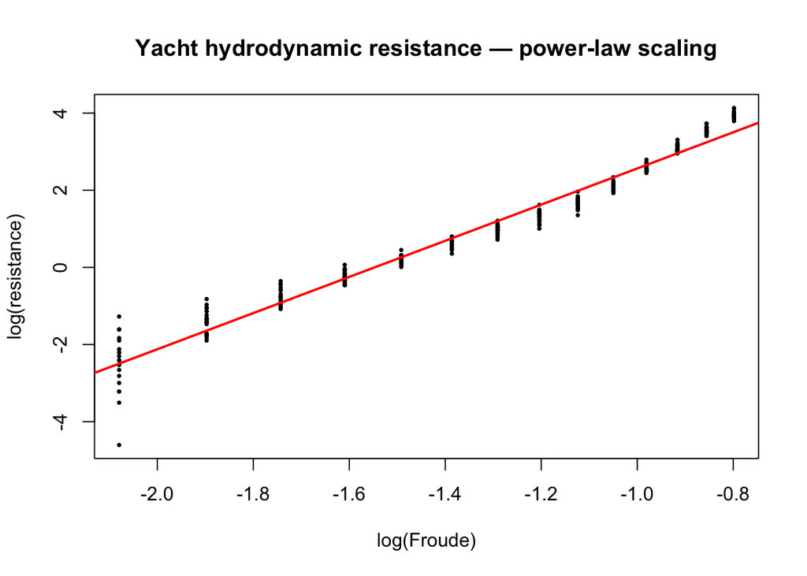

```r
# The power-law in Fn is best seen on log-log axes;
# resistance > 0 everywhere (min = 0.01), so plain log() needs no offset
plot(log(yh$Froude), log(yh$resistance),
     pch = 16, cex = 0.5,
     xlab = "log(Froude)", ylab = "log(resistance)",
     main = "Yacht hydrodynamic resistance — power-law scaling")
abline(lm(log(resistance) ~ log(Froude), data = yh),
       col = "red", lwd = 2)
```

## 1. Log-log regression (Bayesian, reference prior)

We fit the log-log model
$$\log(\mathrm{resistance}) = \beta_0 +
\beta_F\,\log(\mathrm{Froude})
+ \sum_{k=1}^{5}\beta_k\,\mathrm{hull}_k + \varepsilon,
\qquad \varepsilon \sim \mathcal N(0,\sigma^2),$$
with the non-informative reference (Jeffreys) prior $\pi(\beta\mid\sigma^2)\propto 1$, $\pi(\sigma^2)\propto 1/\sigma^2$. The smallest resistance is $0.01>0$, so the logarithm is well defined and no offset is needed. Under this prior the marginal posterior of each coefficient is a Student-$t$ centred at the OLS estimate $\hat\beta$, and the **posterior credible intervals are numerically identical to the OLS confidence intervals**. We can therefore read the full Bayesian inference straight off `lm()`: point estimates from `coef()`, 95% credible intervals from `confint()`, and any posterior probability (such as $P(\beta_F>4)$) from the Student-$t$. The goal is to verify the physical expectation $\beta_F\approx 4$.

```r
set.seed(2026)
yh$log_res <- log(yh$resistance)   # no offset: min(resistance) = 0.01 > 0
yh$log_Fr  <- log(yh$Froude)

fit <- lm(log_res ~ log_Fr + LCB + prismatic + L_disp + beam_draught + L_beam, data = yh)

## reference prior => credible intervals = OLS confidence intervals
round(cbind(estimate = coef(fit), confint(fit)), 4)
```

```
##              estimate   2.5 % 97.5 %
## (Intercept)    7.1834  5.2483 9.1186
## log_Fr         4.6905  4.5964 4.7845
## LCB            0.0216 -0.0025 0.0457
## prismatic     -0.6212 -3.7711 2.5286
## L_disp         0.4648 -0.5456 1.4752
## beam_draught  -0.0664 -0.4602 0.3275
## L_beam        -0.4640 -1.4769 0.5488
```

```r
cat("R^2 =", round(summary(fit)$r.squared, 4),
    "  residual sd =", round(summary(fit)$sigma, 4), "\n")
```

```
## R^2 = 0.9697   residual sd = 0.3248
```

The posterior of the Froude exponent is sharply concentrated around 4.69, well above the textbook value of 4 – the empirical power law is slightly steeper than $Fn^4$.

```r
cf <- summary(fit)$coefficients
bF <- cf["log_Fr", "Estimate"]; se <- cf["log_Fr", "Std. Error"]; df <- fit$df.residual
ci <- confint(fit)["log_Fr", ]
## beta_F | y ~ t_df centred at bF with scale se  =>  P(beta_F > 4)
cat(sprintf("beta_F: mean = %.3f, 95%% CI = [%.3f, %.3f], P(beta_F > 4) = %.3f\n",
            bF, ci[1], ci[2], pt((bF - 4) / se, df = df)))
```

```
## beta_F: mean = 4.690, 95% CI = [4.596, 4.785], P(beta_F > 4) = 1.000
```

None of the five hull form factors is individually credible once `Froude` is in the model (every 95% interval contains zero); this redundancy is addressed by the BAS/BMA model selection in part 2.

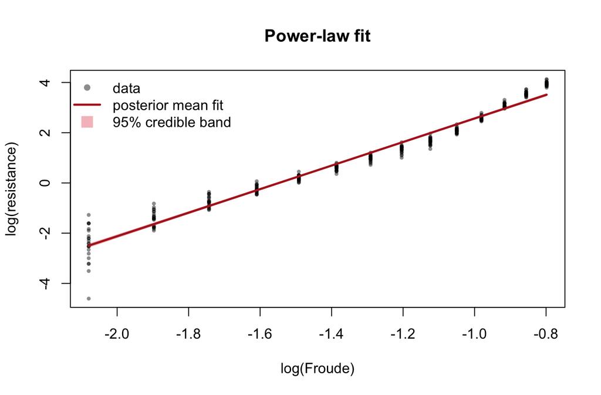

```r
## log-log scatter with posterior-mean line and 95% credible band
##   (= OLS confidence band under the reference prior)
hull_means <- colMeans(yh[, c("LCB","prismatic","L_disp","beam_draught","L_beam")])
xg   <- seq(min(yh$log_Fr), max(yh$log_Fr), length.out = 120)
band <- predict(fit, data.frame(log_Fr = xg, as.list(hull_means)), interval = "confidence")
band_col <- rgb(.85, .1, .1, .30)
plot(yh$log_Fr, yh$log_res, pch = 16, cex = 0.6, col = rgb(0,0,0,0.45),
     xlab = "log(Froude)", ylab = "log(resistance)", main = "Power-law fit")
polygon(c(xg, rev(xg)), c(band[, "lwr"], rev(band[, "upr"])), col = band_col, border = NA)
lines(xg, band[, "fit"], col = "firebrick", lwd = 2.4)
legend("topleft", bty = "n",
       legend = c("data", "posterior mean fit", "95% credible band"),
       pch = c(16, NA, 15), lty = c(NA, 1, NA), lwd = c(NA, 2.4, NA),
       pt.cex = c(1, NA, 1.8), col = c(rgb(0,0,0,0.45), "firebrick", band_col))
```

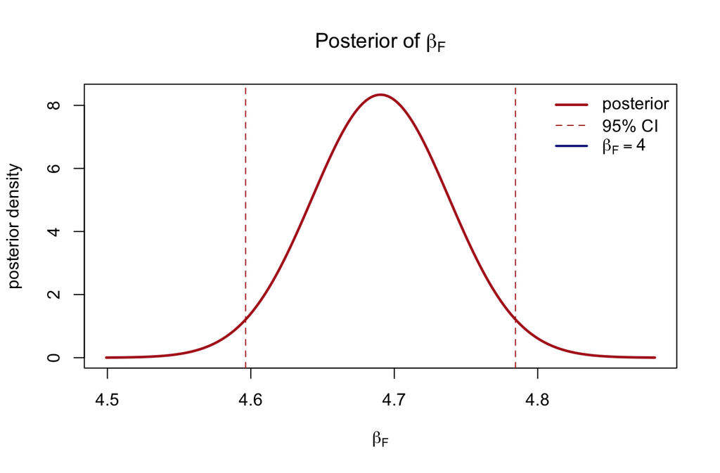

```r
## posterior of beta_F: Student-t centred at the OLS estimate
xb <- seq(bF - 4 * se, bF + 4 * se, length.out = 200)
plot(xb, dt((xb - bF) / se, df) / se, type = "l", col = "firebrick", lwd = 2.4,
     main = expression("Posterior of "*beta[F]),
     xlab = expression(beta[F]), ylab = "posterior density")
abline(v = ci, col = "firebrick", lty = 2)
abline(v = 4, col = "navy", lwd = 2)
legend("topright", bty = "n", lwd = c(2.4, 1, 2), lty = c(1, 2, 1),
       col = c("firebrick", "firebrick", "navy"),
       legend = c("posterior", "95% CI", expression(beta[F] == 4)))
```

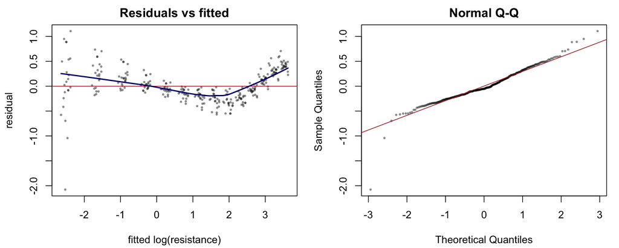

```r
op <- par(mfrow = c(1, 2), mar = c(4.2, 4.2, 2, 1))
plot(fitted(fit), resid(fit), pch = 16, cex = 0.5, col = rgb(0,0,0,0.45),
     xlab = "fitted log(resistance)", ylab = "residual", main = "Residuals vs fitted")
abline(h = 0, col = "firebrick"); lines(lowess(fitted(fit), resid(fit)), col = "navy", lwd = 2)
qqnorm(resid(fit), pch = 16, cex = 0.5, col = rgb(0,0,0,0.45), main = "Normal Q-Q")
qqline(resid(fit), col = "firebrick")
```

```r
par(op)
```

The residuals show a $\cup$-shaped curvature (the local Froude exponent grows with speed) and a variance that shrinks as the fitted value grows (heteroscedasticity). Both defects motivate the heteroscedasticity-corrected nonlinear model of parts 3-4.

### Sensitivity check: independent informative priors (Gibbs sampler)

The reference prior above is deliberately *objective*: the data alone estimate $\beta_F$, and we then **verify** the result against the physical value 4. A complementary check *encodes* the physics in the prior and asks how strongly it must insist on 4 before it overrides the data. We replace the reference prior with **independent proper priors**
$$\beta_F\sim\mathcal
N(4,\tau^2),\qquad \beta_j\sim\mathcal N(0,100^2)\ \ (j\neq F),\qquad
\sigma^2\sim\text{Inv-Gamma}(10^{-3},10^{-3}),$$
all components mutually independent. Because $\beta$ and $\sigma^2$ are now independent a priori (unlike the conjugate Normal-Inverse-Gamma family, where $\mathrm{Var}(\beta\mid\sigma^2)\propto\sigma^2$), the joint posterior has no closed form – but both full conditionals are standard, so we sample it with a **Gibbs sampler** and sweep the prior strength $\tau\in\{0.05,0.1,0.2,0.5\}$.

```r
## Full conditionals of the independent (semi-conjugate) prior:
##   beta | sigma^2, y    ~ N( V (S0^{-1} m0 + X'y / sigma^2), V ),
##                          with V = (S0^{-1} + X'X / sigma^2)^{-1}
##   sigma^2 | beta, y    ~ Inv-Gamma( a0 + n/2, b0 + ||y - X beta||^2 / 2 )
set.seed(2026)
X <- model.matrix(fit); y <- yh$log_res
n <- nrow(X); p <- ncol(X)
fr  <- which(colnames(X) == "log_Fr")
XtX <- crossprod(X); Xty <- crossprod(X, y)

gibbs_betaF <- function(tau, n_iter = 10000, burn = 2000) {
  m0  <- rep(0, p); m0[fr] <- 4            # physics prior centred at 4 on beta_F only
  psd <- rep(100, p); psd[fr] <- tau       # vague-but-proper N(0, 100^2) elsewhere
  S0_inv <- diag(1 / psd^2)
  a0 <- 1e-3; b0 <- 1e-3
  beta <- coef(fit); sig2 <- summary(fit)$sigma^2
  keep <- numeric(n_iter - burn)
  for (it in seq_len(n_iter)) {
    V    <- chol2inv(chol(S0_inv + XtX / sig2))
    mu   <- V %*% (S0_inv %*% m0 + Xty / sig2)
    beta <- as.vector(mu + t(chol(V)) %*% rnorm(p))
    sig2 <- 1 / rgamma(1, a0 + n / 2, b0 + sum((y - X %*% beta)^2) / 2)
    if (it > burn) keep[it - burn] <- beta[fr]
  }
  keep
}

taus  <- c(0.05, 0.1, 0.2, 0.5)
draws <- lapply(taus, gibbs_betaF)

tab <- t(sapply(draws, function(d)
  c(mean = mean(d), q2.5 = unname(quantile(d, .025)),
    q97.5 = unname(quantile(d, .975)), P_gt4 = mean(d > 4))))
rownames(tab) <- sprintf("tau = %.2f", taus)
## reference row: closed-form Student-t posterior (= OLS confint)
ref <- c(bF, ci[1], ci[2], 1 - pt((4 - bF) / se, df))
round(rbind(tab, reference = ref), 3)
```

```
##             mean  q2.5 q97.5 P_gt4
## tau = 0.05 4.331 4.253 4.406     1
## tau = 0.10 4.558 4.468 4.644     1
## tau = 0.20 4.653 4.564 4.746     1
## tau = 0.50 4.684 4.592 4.778     1
## reference  4.690 4.596 4.785     1
```

```r
## crude ACF-based effective sample size, as an MCMC sanity check
ess <- sapply(draws, function(d) {
  ac <- acf(d, lag.max = 50, plot = FALSE)$acf[-1]
  length(d) / (1 + 2 * sum(ac[ac > 0]))
})
cat("approx ESS for beta_F:", round(ess), "\n")
```

```
## approx ESS for beta_F: 4044 4893 5914 6076
```

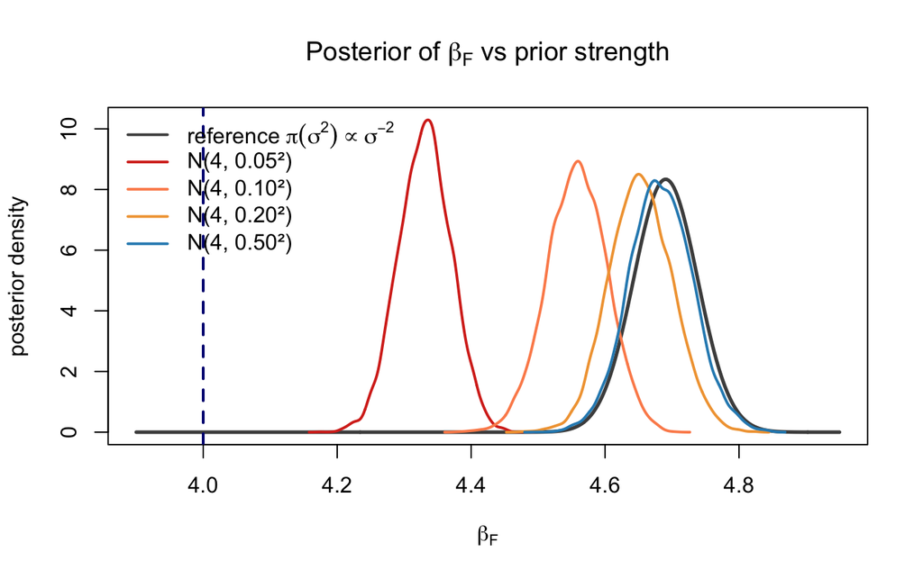

```r
draw_overlay <- function() {
  cols <- c("#d7301f", "#fc8d59", "#f1a340", "#2b8cbe")
  xb <- seq(3.9, 4.95, length.out = 400)
  plot(xb, dt((xb - bF) / se, df) / se, type = "l", lwd = 2.6, col = "grey30",
       main = expression("Posterior of " * beta[F] * " vs prior strength"),
       xlab = expression(beta[F]), ylab = "posterior density",
       ylim = c(0, max(sapply(draws, function(d) max(density(d)$y)),
                       dt(0, df) / se)))
  for (i in seq_along(taus)) lines(density(draws[[i]]), col = cols[i], lwd = 2)
  abline(v = 4, col = "navy", lty = 2, lwd = 2)
  legend("topleft", bty = "n", lwd = 2, col = c("grey30", cols),
         legend = c(expression("reference " * pi(sigma^2) %prop% sigma^-2),
                    sprintf("N(4, %.2f²)", taus)))
}
draw_overlay()
```

```r
## keep the figure used by the report in sync with the notebook
pdf("figures/posterior_betaF_prior.pdf", width = 7, height = 4.4)
draw_overlay(); invisible(dev.off())
```

With $\tau=0.5$ the informative analysis reproduces the reference result ($\beta_F\approx4.69$). Tightening the prior pulls the posterior mean toward 4, but only the near-dogmatic $\tau=0.05$ (prior 95% interval roughly $[3.9,4.1]$) drags it as far as $4.33$ – and even then $P(\beta_F>4\mid y)=1$. For any moderately diffuse physical prior ($\tau\ge0.1$) the likelihood dominates and the posterior mean stays in $4.56$–$4.68$. The conclusion that the empirical exponent is genuinely steeper than $Fn^4$ is therefore **robust to the prior**: it is a feature of the $n=308$ observations, not an artifact of the non-informative choice – a clean illustration of prior–data conflict, where an informative likelihood overwhelms all but an unreasonably confident prior.

## 2. BAS / BMA model selection over hull covariates

The first model already shows the main physical effect: `log_Fr` is overwhelmingly important. The second question is more subtle: **after Froude is already in the model**, do any of the five hull-geometry variables still add useful information?

We answer this with **Bayesian Adaptive Sampling / Bayesian Model Averaging**. In this project the model space is small: there are five optional hull covariates, so there are only $2^5 = 32$ possible submodels. We keep `log_Fr` in every model and let `bas.lm` enumerate every combination of

`LCB`, `prismatic`, `L_disp`, `beam_draught`, and `L_beam`.

The key output is the **posterior inclusion probability** (PIP): the posterior probability that a variable belongs in the regression model. A PIP near 1 means strong evidence that the variable carries signal; a PIP near 0.5 is weak/ambiguous; a small PIP means little evidence once the other variables and Froude are considered.

```r
if (!requireNamespace("BAS", quietly = TRUE)) {
  stop("Package 'BAS' is required. Install it with install.packages('BAS') before knitting.")
}
library(BAS)

# Optional hull-geometry covariates. These are the five variables requested in the project.
hull_covariates <- c("LCB", "prismatic", "L_disp", "beam_draught", "L_beam")

# Sanity check: fail loudly if a requested covariate is missing or misspelled.
stopifnot(all(c("log_res", "log_Fr", hull_covariates) %in% names(yh)))

# In the model-selection step, log_Fr must be present in every model.
# The five hull covariates are optional, so bas.lm enumerates 2^5 = 32 submodels.
bas_fit <- bas.lm(
  log_res ~ log_Fr + LCB + prismatic + L_disp + beam_draught + L_beam,
  data = yh,
  prior = "BIC",
  modelprior = uniform(),
  method = "deterministic",
  n.models = 2^length(hull_covariates),
  include.always = ~ log_Fr,
  force.heredity = FALSE
)

# Check that the model space has really been fully enumerated.
n_models_expected <- 2^length(hull_covariates)
n_models_observed <- length(bas_fit$postprobs)
cat("Number of models enumerated:", n_models_observed, "\n")
```

```
## Number of models enumerated: 32
```

```r
stopifnot(n_models_observed == n_models_expected)

# BAS may store the selected variables either as a list of indices or as a matrix,
# depending on the package version. The following code converts both cases into
# a stable 0/1 model-inclusion matrix.
term_names <- c("(Intercept)", "log_Fr", hull_covariates)

make_which_matrix <- function(which_obj, term_names) {
  if (is.list(which_obj) && !is.matrix(which_obj)) {
    out <- t(sapply(which_obj, function(idx) {
      # BAS indexes terms from 0: 0 = intercept, 1 = log_Fr, 2:6 = hull covariates.
      as.integer((seq_along(term_names) - 1) %in% idx)
    }))
    colnames(out) <- term_names
    return(out)
  }

  out <- as.matrix(which_obj)
  if (ncol(out) == length(term_names)) {
    colnames(out) <- term_names
  } else if (ncol(out) == length(term_names) - 1) {
    colnames(out) <- term_names[-1]
  } else {
    stop("Unexpected format for bas_fit$which. Inspect str(bas_fit$which).")
  }
  out
}

model_matrix <- as.data.frame(make_which_matrix(bas_fit$which, term_names))

# Normalise posterior model probabilities and attach them to the model matrix.
post_prob <- bas_fit$postprobs / sum(bas_fit$postprobs)
model_matrix$post_prob <- post_prob

# Check that log_Fr is indeed included in all models and that the five hull terms exist.
stopifnot(all(model_matrix$log_Fr == 1))
stopifnot(all(hull_covariates %in% names(model_matrix)))

# Posterior inclusion probabilities computed directly from the enumerated models.
# This avoids relying on version-dependent names in bas_fit$probne0.
pip_hull <- sapply(hull_covariates, function(v) {
  sum(model_matrix[[v]] * model_matrix$post_prob)
})

pip_sorted <- sort(pip_hull, decreasing = TRUE)
pip_table <- data.frame(
  covariate = names(pip_sorted),
  PIP = round(as.numeric(pip_sorted), 3),
  evidence = ifelse(pip_sorted >= 0.75, "strong",
                    ifelse(pip_sorted >= 0.50, "moderate", "weak")),
  row.names = NULL
)

pip_table
```

| covariate | PIP | evidence |
| --- | --- | --- |
| beam_draught | 0.565 | moderate |
| prismatic | 0.265 | weak |
| LCB | 0.210 | weak |
| L_disp | 0.206 | weak |
| L_beam | 0.192 | weak |

```r
# Explicit answer to the project question:
# "which of LCB, prismatic, L/disp, B/draught, L/beam carry signal once Froude is in the model?"
label_map <- c(
  LCB = "LCB",
  prismatic = "prismatic",
  L_disp = "L/disp",
  beam_draught = "B/draught",
  L_beam = "L/beam"
)

signal_table <- data.frame(
  requested_name = unname(label_map[pip_table$covariate]),
  R_variable = pip_table$covariate,
  PIP = pip_table$PIP,
  evidence = pip_table$evidence,
  answer = ifelse(
    pip_table$evidence == "moderate",
    "carries moderate signal",
    "weak evidence; not retained as carrying signal"
  ),
  row.names = NULL
)

signal_table
```

| requested_name | R_variable | PIP | evidence | answer |
| --- | --- | --- | --- | --- |
| B/draught | beam_draught | 0.565 | moderate | carries moderate signal |
| prismatic | prismatic | 0.265 | weak | weak evidence; not retained as carrying signal |
| LCB | LCB | 0.210 | weak | weak evidence; not retained as carrying signal |
| L/disp | L_disp | 0.206 | weak | weak evidence; not retained as carrying signal |
| L/beam | L_beam | 0.192 | weak | weak evidence; not retained as carrying signal |

```r
best_covariate <- pip_table$covariate[1]
best_requested_name <- unname(label_map[best_covariate])
best_pip <- pip_table$PIP[1]

cat("Largest PIP:", best_requested_name, "(", best_covariate, ") =", best_pip, "\n")
```

```
## Largest PIP: B/draught ( beam_draught ) = 0.565
```

```r
cat(
  "Answer:",
  best_requested_name, "(", best_covariate, ") is the only hull-geometry covariate with moderate evidence of carrying signal once Froude is included; the remaining hull covariates show weak evidence.\n"
)
```

```
## Answer: B/draught ( beam_draught ) is the only hull-geometry covariate with moderate evidence of carrying signal once Froude is included; the remaining hull covariates show weak evidence.
```

**Explicit answer to the project question.** The covariate that carries signal once `Froude` is in the model is **B/draught**, implemented in the data as `beam_draught`. In the rendered BAS/BMA output its PIP is about **0.565**, so the evidence is **moderate** rather than strong. The other four hull-geometry covariates – `LCB`, `prismatic`, `L_disp` (L/disp), and `L_beam` (L/beam) – have PIP values below 0.50, so they show weak evidence and are not retained as variables that clearly carry signal.

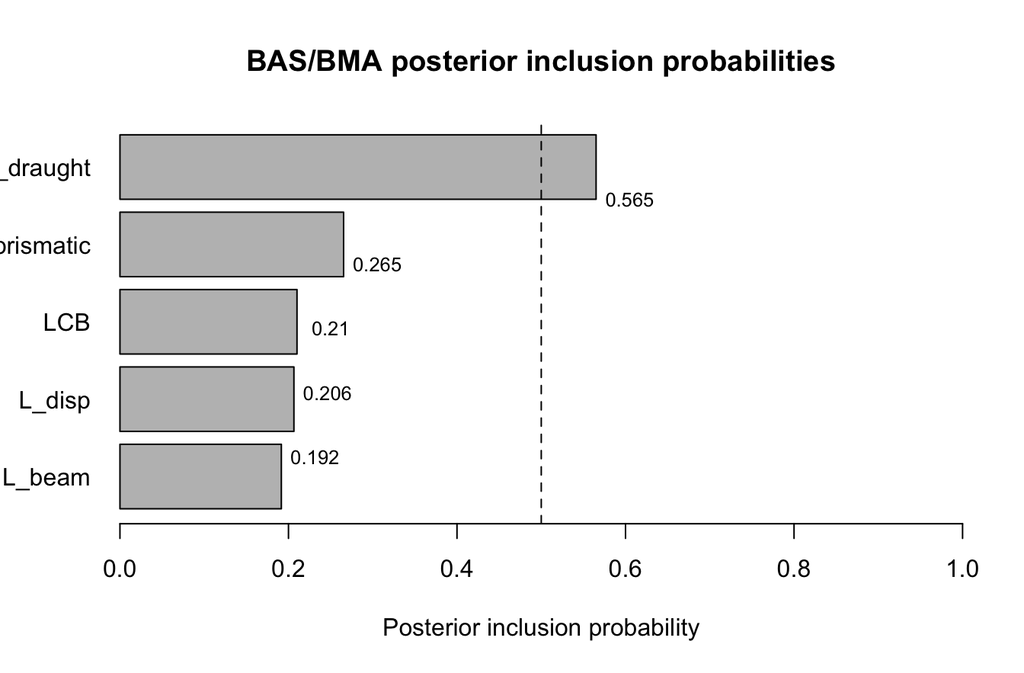

```r
barplot(
  rev(pip_sorted),
  horiz = TRUE,
  las = 1,
  xlim = c(0, 1),
  xlab = "Posterior inclusion probability",
  main = "BAS/BMA posterior inclusion probabilities"
)
abline(v = 0.5, lty = 2)
text(
  x = rev(pip_sorted) + 0.04,
  y = seq_along(pip_sorted),
  labels = round(rev(pip_sorted), 3),
  cex = 0.8
)
```

For transparency, we also print the most probable models. The formula below should be read as: `log_Fr` is always included; the listed hull variables are the extra terms selected in that submodel.

```r
top_models <- model_matrix[
  order(-model_matrix$post_prob),
  c(hull_covariates, "post_prob")
]

top_models$model <- apply(
  top_models[, hull_covariates, drop = FALSE],
  1,
  function(z) {
    chosen <- hull_covariates[as.logical(z)]
    if (length(chosen) == 0) {
      "log_Fr only"
    } else {
      paste("log_Fr +", paste(chosen, collapse = " + "))
    }
  }
)

top_models <- top_models[, c("model", "post_prob")]
head(transform(top_models, post_prob = round(post_prob, 3)), 10)
```

|  | model | post_prob |
| --- | --- | --- |
| 14 | log_Fr + beam_draught | 0.234 |
| 16 | log_Fr only | 0.176 |
| 18 | log_Fr + prismatic + beam_draught | 0.153 |
| 12 | log_Fr + L_disp + L_beam | 0.083 |
| 28 | log_Fr + LCB + beam_draught | 0.063 |
| 30 | log_Fr + LCB | 0.046 |
| 21 | log_Fr + LCB + prismatic + beam_draught | 0.040 |
| 17 | log_Fr + L_disp | 0.028 |
| 26 | log_Fr + LCB + L_disp + L_beam | 0.023 |
| 20 | log_Fr + prismatic | 0.021 |

Finally, we report the Bayesian model-averaged coefficient summary. These coefficients are averaged over all 32 models, so variables with low inclusion probability are automatically shrunk toward zero in the BMA estimate.

```r
bma_coef <- coef(bas_fit)
print(bma_coef)
```

```
##
##  Marginal Posterior Summaries of Coefficients:
##
##  Using  BMA
##
##  Based on the top  32 models
##               post mean  post SD    post p(B != 0)
## Intercept      1.084502   0.018648   1.000000
## log_Fr         4.690455   0.048177   1.000000
## LCB            0.004521   0.010425   0.210113
## prismatic     -0.452074   0.885927   0.265424
## L_disp         0.050626   0.132492   0.206460
## beam_draught   0.050565   0.060837   0.565078
## L_beam        -0.047164   0.130663   0.191532
```

### Prior sensitivity analysis for BAS/BMA

The project instructions ask for posterior analysis and, where appropriate, sensitivity analysis. Since the baseline PIP values are not high, we should check whether the conclusion about hull-geometry covariates depends strongly on the prior used in `bas.lm`. Therefore, we repeat the same BAS/BMA enumeration with three standard choices from the linear-regression/model-selection material:

- `prior = "BIC"`: the baseline reference/BIC approximation used above;
- `prior = "g-prior"`, with `alpha = n`: Zellner’s $g$-prior with $g=n$, a common weakly informative choice;
- `prior = "JZS"`: Jeffreys-Zellner-Siow prior, a heavy-tailed alternative to a fixed $g$-prior.

In all cases we keep the same model prior, `modelprior = uniform()`, and we still force `log_Fr` to be present in every model. Therefore, each sensitivity run answers the same question: **among `LCB`, `prismatic`, `L_disp`, `beam_draught`, and `L_beam`, which variables carry signal once Froude is already included?**

```r
fit_bas_prior <- function(prior_name, alpha = NULL) {
  args <- list(
    formula = log_res ~ log_Fr + LCB + prismatic + L_disp + beam_draught + L_beam,
    data = yh,
    prior = prior_name,
    modelprior = uniform(),
    method = "deterministic",
    n.models = n_models_expected,
    include.always = ~ log_Fr,
    force.heredity = FALSE
  )
  if (!is.null(alpha)) {
    args$alpha <- alpha
  }
  do.call(bas.lm, args)
}

extract_pip_table <- function(fit_obj, prior_label) {
  mm <- as.data.frame(make_which_matrix(fit_obj$which, term_names))
  pp <- fit_obj$postprobs / sum(fit_obj$postprobs)
  mm$post_prob <- pp

  # Same checks as in the baseline analysis.
  stopifnot(length(pp) == nrow(mm))
  stopifnot(length(pp) == n_models_expected)
  stopifnot(all(mm$log_Fr == 1))

  pip <- sapply(hull_covariates, function(v) {
    sum(mm[[v]] * mm$post_prob)
  })

  out <- data.frame(
    prior = prior_label,
    requested_name = unname(label_map[names(pip)]),
    R_variable = names(pip),
    PIP = round(as.numeric(pip), 3),
    evidence = ifelse(pip >= 0.75, "strong",
                      ifelse(pip >= 0.50, "moderate", "weak")),
    row.names = NULL
  )
  out[order(-out$PIP), ]
}

bas_fits_sensitivity <- list(
  "BIC / reference" = bas_fit,
  "g-prior (g = n)" = fit_bas_prior("g-prior", alpha = nrow(yh)),
  "JZS" = fit_bas_prior("JZS")
)

sensitivity_table <- do.call(
  rbind,
  lapply(names(bas_fits_sensitivity), function(pr) {
    extract_pip_table(bas_fits_sensitivity[[pr]], pr)
  })
)
rownames(sensitivity_table) <- NULL

# Full sensitivity table: PIP for every hull covariate under every prior.
sensitivity_table
```

| prior | requested_name | R_variable | PIP | evidence |
| --- | --- | --- | --- | --- |
| BIC / reference | B/draught | beam_draught | 0.565 | moderate |
| BIC / reference | prismatic | prismatic | 0.265 | weak |
| BIC / reference | LCB | LCB | 0.210 | weak |
| BIC / reference | L/disp | L_disp | 0.206 | weak |
| BIC / reference | L/beam | L_beam | 0.192 | weak |
| g-prior (g = n) | B/draught | beam_draught | 0.499 | weak |
| g-prior (g = n) | prismatic | prismatic | 0.217 | weak |
| g-prior (g = n) | LCB | LCB | 0.186 | weak |
| g-prior (g = n) | L/disp | L_disp | 0.182 | weak |
| g-prior (g = n) | L/beam | L_beam | 0.166 | weak |

[output cut: 5 more lines]

```r
# Most supported hull covariate under each prior.
top_by_prior <- do.call(
  rbind,
  lapply(split(sensitivity_table, sensitivity_table$prior), function(d) {
    d[which.max(d$PIP), ]
  })
)
rownames(top_by_prior) <- NULL

top_by_prior
```

| prior | requested_name | R_variable | PIP | evidence |
| --- | --- | --- | --- | --- |
| BIC / reference | B/draught | beam_draught | 0.565 | moderate |
| g-prior (g = n) | B/draught | beam_draught | 0.499 | weak |
| JZS | B/draught | beam_draught | 0.243 | weak |

```r
# Variables that reach at least moderate evidence under every prior.
moderate_sets <- lapply(split(sensitivity_table, sensitivity_table$prior), function(d) {
  d$R_variable[d$PIP >= 0.50]
})
robust_moderate <- Reduce(intersect, moderate_sets)
robust_moderate_names <- unname(label_map[robust_moderate])

if (length(robust_moderate) == 0) {
  sensitivity_answer <- paste(
    "No hull covariate reaches PIP >= 0.50 under all priors.",
    "The safest conclusion is that hull effects are weak and prior-sensitive once Froude is included."
  )
} else {
  sensitivity_answer <- paste(
    paste(robust_moderate_names, collapse = ", "),
    "is/are the hull covariate(s) with at least moderate evidence under all priors.",
    "The remaining hull covariates have weak or prior-sensitive support."
  )
}

cat("Sensitivity answer:", sensitivity_answer, "\n")
```

```
## Sensitivity answer: No hull covariate reaches PIP >= 0.50 under all priors. The safest conclusion is that hull effects are weak and prior-sensitive once Froude is included.
```

The sensitivity analysis is important because the baseline PIP values are modest. It avoids overclaiming from a single prior. If the same hull covariate remains the top candidate or the only variable with at least moderate inclusion probability across `BIC`, Zellner’s `g-prior`, and `JZS`, then it is reasonable to carry that variable forward into the nonlinear model. If the conclusion changes across priors, then the correct interpretation is more cautious: the data do not strongly identify a stable hull-geometry effect once Froude is included.

**Sensitivity-based interpretation.** No hull covariate reaches PIP >= 0.50 under all priors. The safest conclusion is that hull effects are weak and prior-sensitive once Froude is included.

**Conclusion of part 2.** The BAS/BMA analysis confirms that `log_Fr` is the dominant explanatory variable and that the hull-geometry covariates provide, at most, secondary information once Froude is already included in the model. Under the baseline BIC/reference specification, **B/draught** (`beam_draught`) has the largest posterior inclusion probability, approximately **0.565**, so it is the main candidate among the five hull covariates. However, this is only moderate evidence, not strong evidence.

The prior sensitivity analysis gives a more cautious interpretation. When the BAS/BMA enumeration is repeated using alternative priors, such as Zellner’s `g-prior` and the `JZS` prior, no hull covariate reaches PIP ≥ 0.50 under all prior choices. Therefore, the contribution of the hull-geometry variables is not fully robust to the prior specification.

Overall, the safest conclusion is that **Froude explains the main resistance scaling**, while the hull-geometry effects are weak to moderate and prior-sensitive. Among them, **B/draught** (`beam_draught`) is the most defensible reduced candidate to carry forward into the nonlinear heteroscedasticity-corrected model of part 3, but it should also be compared with a no-hull model as a sensitivity check.

## 3. Heteroscedasticity-corrected nonlinear model (JAGS, slice sampling)

The log-log model of part 1 assumes *multiplicative* lognormal errors (a noise standard deviation proportional to the resistance), while a constant-variance additive model goes to the opposite extreme of a single $\sigma$. The residual diagnostics below show that neither extreme is right: on the original scale the residual spread clearly *grows* with the fitted resistance, so a constant $\sigma$ does **not** actually correct the heteroscedasticity. Because the residuary resistance is strictly positive, we model it on its original scale with a **Gamma** likelihood, keeping the power-law mean but **learning how the variance grows** instead of fixing it. Parametrizing the Gamma through its mean and variance,

$$\mathrm{resistance}_i \;\sim\;
\mathrm{Gamma}\!\Big(\text{shape}_i=\tfrac{\mu_i^2}{\sigma_i^2},\
\text{rate}_i=\tfrac{\mu_i}{\sigma_i^2}\Big),
\qquad \mathbb E(y_i)=\mu_i,\quad
\mathrm{Var}(y_i)=\sigma_i^2,$$

with mean and standard deviation

$$\mu_i =
k\,\mathrm{Froude}_i^{\gamma_F}\,\exp\{\beta_B\,\mathrm{bd}_i\},
\qquad \sigma_i = \sigma_0\,\mu_i^{\delta}.$$

The exponent $\delta$ is an unknown parameter that **interpolates between the two error regimes**: $\delta=0$ gives a constant variance, while $\delta=1$ gives a noise standard deviation proportional to the mean (constant coefficient of variation, the multiplicative/lognormal regime of part 1). Letting the data estimate $\delta$ — i.e. *learning the variance function* rather than assuming it — is the actual heteroscedasticity correction.

Following the BAS result of part 2 we keep only `beam_draught` (bd) and fit two models: **M0** (Froude only) and **M1** (Froude + beam_draught). For the mean parameters the priors are $\log k\sim\mathcal N(0,10^2)$, $\gamma_F\sim\mathcal N(4,2^2)$ (weakly informative, centred at the physical value) and $\beta_B\sim\mathcal N(0,2^2)$. For the variance function we use weakly-informative priors on the two new parameters, $\log\sigma_0\sim\mathcal N(0,10^2)$ and $\delta\sim\mathcal N(0,1^2)$; the prior on $\delta$ is centred at $0$ (homoscedasticity) so that the data, not the prior, decide whether and how fast the variance grows. As a sensitivity check the $\gamma_F$ prior is also replaced by a vague $\mathcal N(0,10^2)$ and an informative $\mathcal N(4,0.5^2)$.

Both the mean and the variance depend on the parameters through the nonlinear exponential link, so the likelihood is not conjugate with any standard prior and the posterior has no closed form. We therefore sample it with **JAGS**, the Gibbs-sampling engine used in the course, coding the mean as $\mu_i=\exp(X_i^\top\theta)$ and the moment-matched Gamma shape and rate as above. For a model like this one — no conjugate full conditionals anywhere, because of the exponential mean and the mean-dependent variance — JAGS automatically assigns its univariate **slice sampler** (`base::RealSlicer`) to each of $\log k,\gamma_F,\beta_B,\log\sigma_0$ and $\delta$; we confirm this with `list.samplers()`. Slice sampling needs no proposal tuning and has no accept/reject step, which is why it is a convenient default for awkward, non-conjugate posteriors. We run four chains started from over-dispersed values of $\gamma_F$ and $\delta$ so that the Gelman–Rubin statistic is a meaningful convergence check.

```r
y_res <- yh$resistance
n_obs <- length(y_res)

## centre covariates at a y^2-weighted mean: removes the strong posterior
## correlation between b0 and gamma_F that ruins mixing with plain centring
w_info <- y_res^2 / sum(y_res^2)
mF <- sum(w_info * log(yh$Froude))
mB <- sum(w_info * yh$beam_draught)
xF_c <- log(yh$Froude)  - mF
xB_c <- yh$beam_draught - mB

X0 <- cbind(intercept = 1, log_Fr = xF_c)                    # M0: Froude only
X1 <- cbind(X0, beam_draught = xB_c)                         # M1: + beam_draught

save_current_pdf <- function(filename, width, height) {
  dir.create("figures", showWarnings = FALSE)
  dev.copy(pdf, file = file.path("figures", filename),
           width = width, height = height)
  invisible(dev.off())
}
```

```r
if (!requireNamespace("rjags", quietly = TRUE)) {
  stop("Package 'rjags' and the JAGS program are required. Install JAGS (https://mcmc-jags.sourceforge.io), then install.packages('rjags').")
}
library(rjags)
library(coda)

## Heteroscedastic nonlinear model, written for JAGS.
##   y_i ~ Gamma(shape_i, rate_i) moment-matched to mean mu_i and variance sigma_i^2,
##   mu_i = exp(X_i %*% theta),  sigma_i = sigma0 * mu_i^delta,
##   shape_i = mu_i^2 / sigma_i^2,  rate_i = mu_i / sigma_i^2.
## The Gamma keeps the response on its positive support (resistance > 0).
## Nothing here is conjugate (the exp link and the mean-dependent variance break
## conjugacy), so JAGS automatically assigns its univariate SLICE sampler
## (base::RealSlicer) to every parameter -- verified below with list.samplers().
## theta is kept as a vector node so the monitored columns are theta[1..p],
## matching the rest of the analysis.
jags_hetero <- "
model {
  for (i in 1:n) {
    mu[i]    <- exp(inprod(X[i, ], theta))
    sigma[i] <- sigma0 * pow(mu[i], delta)
    shape[i] <- (mu[i] * mu[i]) / (sigma[i] * sigma[i])
    rate[i]  <- mu[i] / (sigma[i] * sigma[i])
    y[i] ~ dgamma(shape[i], rate[i])
  }
  for (j in 1:p) {
    theta[j] ~ dnorm(prior_mean[j], 1 / (prior_sd[j] * prior_sd[j]))
  }
  logs0  ~ dnorm(0, 1 / 100)   # log sigma0 ~ N(0, 10^2)
  sigma0 <- exp(logs0)
  delta  ~ dnorm(0, 1)         # delta ~ N(0, 1^2);  0 = homoscedastic, 1 = multiplicative
}"

## delta pinned to 0 -> constant-variance (homoscedastic) baseline for comparison.
jags_homo <- "
model {
  for (i in 1:n) {
    mu[i]    <- exp(inprod(X[i, ], theta))
    shape[i] <- (mu[i] * mu[i]) / (sigma0 * sigma0)
    rate[i]  <- mu[i] / (sigma0 * sigma0)
    y[i] ~ dgamma(shape[i], rate[i])
  }
  for (j in 1:p) {
    theta[j] ~ dnorm(prior_mean[j], 1 / (prior_sd[j] * prior_sd[j]))
  }
  logs0  ~ dnorm(0, 1 / 100)
  sigma0 <- exp(logs0)
  delta  <- 0
}"

## Fit the model with JAGS. Chains are over-dispersed in gamma_F (and delta) so
## that Gelman-Rubin is a genuine convergence test; reproducible via .RNG.seed.
run_jags <- function(X, prior_mean, prior_sd, homoscedastic = FALSE,
                     n_chains = 4, n_adapt = 1000, n_burn = 2000,
                     n_iter = 8000, thin = 2,
                     gamma_inits = c(3, 6, 5, 4), delta_inits = c(0, 1, 0.5, 1.2),
                     seed0 = 2026) {
  p <- ncol(X)
  stopifnot(length(prior_mean) == p, length(prior_sd) == p)
  dat <- list(y = y_res, X = X, n = nrow(X), p = p,
              prior_mean = prior_mean, prior_sd = prior_sd)
  theta0 <- coef(lm(log(y_res) ~ X - 1))           # crude start from the log fit

  inits <- lapply(seq_len(n_chains), function(ch) {
    th <- theta0; th[2] <- gamma_inits[ch]
    out <- list(theta = unname(th),
                logs0 = log(sd(y_res - exp(as.vector(X %*% th)))),
                .RNG.name = "base::Mersenne-Twister", .RNG.seed = seed0 + ch)
    if (!homoscedastic) out$delta <- delta_inits[ch]
    out
  })

  jm <- jags.model(textConnection(if (homoscedastic) jags_homo else jags_hetero),
                   data = dat, inits = inits, n.chains = n_chains,
                   n.adapt = n_adapt, quiet = TRUE)
  update(jm, n_burn)                               # burn-in
  samp <- coda.samples(jm, c("theta", "sigma0", "delta"),
                       n.iter = n_iter, thin = thin)
  attr(samp, "samplers") <- unique(names(list.samplers(jm)))
  samp
}
```

```r
## main prior, 4 chains each
fit_M0 <- run_jags(X0, prior_mean = c(0, 4),    prior_sd = c(10, 2))
fit_M1 <- run_jags(X1, prior_mean = c(0, 4, 0), prior_sd = c(10, 2, 2))

## gamma_F prior sensitivity (M1, 2 chains each)
fit_M1_vague  <- run_jags(X1, prior_mean = c(0, 0, 0), prior_sd = c(10, 10, 2),
                          n_chains = 2)
fit_M1_inform <- run_jags(X1, prior_mean = c(0, 4, 0), prior_sd = c(10, 0.5, 2),
                          n_chains = 2)

## Confirm JAGS used the slice sampler for every parameter of this model.
cat("Samplers JAGS assigned (M1):", paste(attr(fit_M1, "samplers"), collapse = ", "), "\n")
```

```
## Samplers JAGS assigned (M1): base::RealSlicer
```

### Convergence diagnostics

JAGS assigns its univariate **slice sampler** (`base::RealSlicer`) to every parameter of this model, because the exponential mean and the mean-dependent variance leave nothing conjugate; the slice sampler is tuning-free (no proposal scale to set) and has no accept/reject step, so the usual Metropolis acceptance-rate diagnostic does not apply here. MCMC draws are only valid posterior samples after the chains have converged, so before any inference we check four things. (1) **Traceplots**: each parameter’s chains should look like stationary noise around a fixed level, with the independently started chains overlapping. (2) **Gelman–Rubin** $\hat R$: the chains were started from deliberately different values of $\gamma_F$ (3, 6, 5, 4) and of $\delta$ (0, 1, 0.5, 1.2); $\hat R$ compares the variance *between* chains to the variance *within* chains, and is $\approx 1$ only when all chains explore the same distribution – we require $\hat R < 1.01$. (3) **Effective sample size (ESS)**: consecutive MCMC draws are autocorrelated, so the kept MCMC draws carry less information than independent samples; ESS is the equivalent number of independent draws, and we want it in the thousands so that posterior quantiles are stable. (4) **Autocorrelation plots**: the autocorrelation of the chain should decay to zero within a few lags; slow decay explains a low ESS.

```r
par_labels <- c("theta[1]" = "b0", "theta[2]" = "gamma_F",
                "theta[3]" = "beta_B", "sigma0" = "sigma0", "delta" = "delta")

diag_table <- function(fit, run) {
  keep <- intersect(varnames(fit), names(par_labels))
  rhat <- gelman.diag(fit[, keep], multivariate = FALSE)$psrf[, 1]
  ess  <- effectiveSize(fit[, keep])
  data.frame(run = run, parameter = unname(par_labels[keep]),
             Rhat = round(rhat, 4), ESS = round(ess), row.names = NULL)
}

rbind(diag_table(fit_M0, "M0 (main prior)"),
      diag_table(fit_M1, "M1 (main prior)"),
      diag_table(fit_M1_vague,  "M1 (vague gamma_F prior)"),
      diag_table(fit_M1_inform, "M1 (informative gamma_F prior)"))
```

| run | parameter | Rhat | ESS |
| --- | --- | --- | --- |
| M0 (main prior) | delta | 1.0017 | 1920 |
| M0 (main prior) | sigma0 | 1.0008 | 2731 |
| M0 (main prior) | b0 | 1.0003 | 3480 |
| M0 (main prior) | gamma_F | 1.0018 | 1876 |
| M1 (main prior) | delta | 1.0000 | 2208 |
| M1 (main prior) | sigma0 | 1.0000 | 3284 |
| M1 (main prior) | b0 | 1.0002 | 4409 |
| M1 (main prior) | gamma_F | 0.9999 | 2182 |
| M1 (main prior) | beta_B | 1.0003 | 13012 |
| M1 (vague gamma_F prior) | delta | 0.9999 | 1227 |

[output cut: 9 more lines]

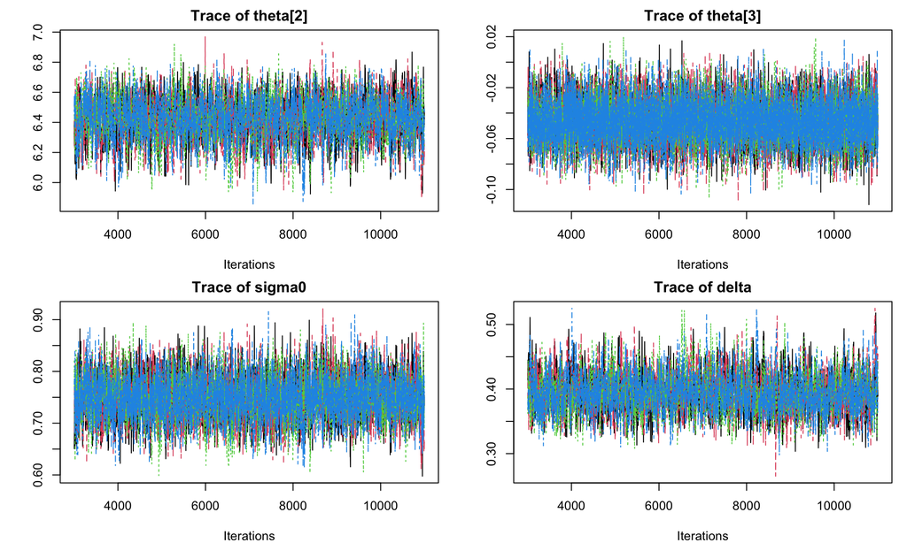

```r
## traceplots + autocorrelation for the headline run (M1, main prior)
op <- par(mfrow = c(2, 2), mar = c(4, 4, 2, 1))
traceplot(fit_M1[, c("theta[2]", "theta[3]", "sigma0", "delta")])
```

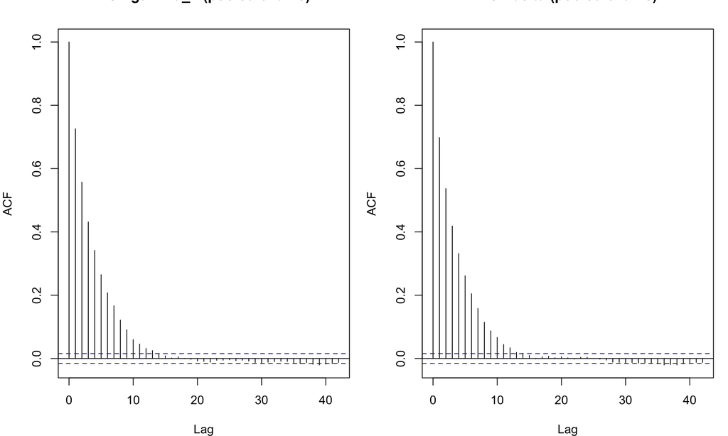

```r
par(op)
save_current_pdf("task3-diagnostics-trace.pdf", width = 10, height = 6)

op <- par(mfrow = c(1, 2), mar = c(4, 4, 2, 1))
acf(as.matrix(fit_M1[, "theta[2]"]), main = "ACF gamma_F (pooled chains)")
acf(as.matrix(fit_M1[, "delta"]),    main = "ACF delta (pooled chains)")
```

```r
par(op)
save_current_pdf("task3-diagnostics-acf.pdf", width = 10, height = 6)
```

All $\hat R$ are $\approx 1$ and the effective sample sizes are comfortably large, so the chains can be pooled for inference.

### Posterior analysis

```r
## back-transform the centred intercept to the physical k for every draw
post_summary <- function(fit, hull = TRUE) {
  d <- as.matrix(fit)
  k <- exp(d[, "theta[1]"] - d[, "theta[2]"] * mF -
             (if (hull) d[, "theta[3]"] * mB else 0))
  out <- cbind(k = k, gamma_F = d[, "theta[2]"],
               beta_B = if (hull) d[, "theta[3]"] else NULL,
               sigma0 = d[, "sigma0"], delta = d[, "delta"])
  t(apply(out, 2, function(z)
    c(mean = mean(z), sd = sd(z),
      `2.5%` = unname(quantile(z, .025)), `50%` = unname(quantile(z, .5)),
      `97.5%` = unname(quantile(z, .975)))))
}

cat("M0 (Froude only):\n")
```

```
## M0 (Froude only):
```

```r
round(post_summary(fit_M0, hull = FALSE), 4)
```

```
##              mean        sd      2.5%       50%     97.5%
## k       7769.1612 1017.3144 5815.5752 7758.2596 9821.1407
## gamma_F    6.3316    0.1482    6.0204    6.3392    6.6047
## sigma0     0.7340    0.0439    0.6490    0.7335    0.8212
## delta      0.4194    0.0316    0.3626    0.4172    0.4871
```

```r
cat("\nM1 (Froude + beam_draught):\n")
```

```
##
## M1 (Froude + beam_draught):
```

```r
round(post_summary(fit_M1), 4)
```

```
##               mean        sd      2.5%        50%      97.5%
## k       10093.6752 1493.0931 7269.8441 10056.4576 13114.0056
## gamma_F     6.4186    0.1401    6.1204     6.4247     6.6778
## beta_B     -0.0463    0.0173   -0.0797    -0.0466    -0.0111
## sigma0      0.7475    0.0418    0.6673     0.7470     0.8318
## delta       0.3950    0.0302    0.3397     0.3932     0.4595
```

```r
gF_draws <- as.matrix(fit_M1)[, "theta[2]"]
bB_draws <- as.matrix(fit_M1)[, "theta[3]"]
dl_draws <- as.matrix(fit_M1)[, "delta"]
cat(sprintf("\nP(gamma_F > 4 | y) = %.4f   P(beta_B < 0 | y) = %.4f   P(delta > 0 | y) = %.4f\n",
            mean(gF_draws > 4), mean(bB_draws < 0), mean(dl_draws > 0)))
```

```
##
## P(gamma_F > 4 | y) = 1.0000   P(beta_B < 0 | y) = 0.9954   P(delta > 0 | y) = 1.0000
```

```r
cat("log-log (part 1) for comparison: beta_F =", round(bF, 3),
    ", 95% CI [", round(ci[1], 3), ",", round(ci[2], 3), "]\n")
```

```
## log-log (part 1) for comparison: beta_F = 4.69 , 95% CI [ 4.596 , 4.785 ]
```

```r
cat("log-log beam_draught 95% CI: [",
    paste(round(confint(fit)["beam_draught", ], 4), collapse = ", "), "]\n")
```

```
## log-log beam_draught 95% CI: [ -0.4602, 0.3275 ]
```

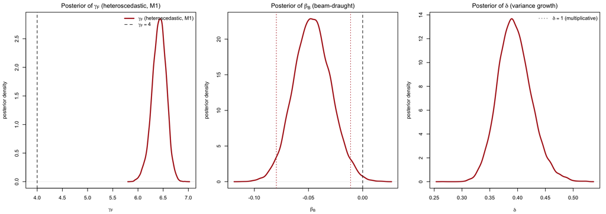

```r
op <- par(mfrow = c(1, 3), mar = c(4.2, 4.2, 2, 1))

## gamma_F (heteroscedastic M1)
dg <- density(gF_draws)
plot(dg, col = "firebrick", lwd = 2.4, xlim = c(3.9, max(dg$x)),
     main = expression("Posterior of "*gamma[F]*" (heteroscedastic, M1)"),
     xlab = expression(gamma[F]), ylab = "posterior density")
abline(v = 4, lty = 2)
legend("topright", bty = "n", lwd = c(2.4, 1), col = c("firebrick", "black"),
       lty = c(1, 2),
       legend = c(expression(gamma[F]*" (heteroscedastic, M1)"),
                  expression(gamma[F] == 4)))

## beam_draught effect: credible once the error model is corrected
plot(density(bB_draws), col = "firebrick", lwd = 2.4,
     main = expression("Posterior of "*beta[B]*" (beam-draught)"),
     xlab = expression(beta[B]), ylab = "posterior density")
abline(v = 0, lty = 2)
abline(v = quantile(bB_draws, c(.025, .975)), col = "firebrick", lty = 3)

## variance-growth exponent delta: 1 = multiplicative (delta = 0 marker removed)
plot(density(dl_draws), col = "firebrick", lwd = 2.4,
     main = expression("Posterior of "*delta*" (variance growth)"),
     xlab = expression(delta), ylab = "posterior density")
abline(v = 1, col = "grey50", lty = 3, lwd = 1)
legend("topright", bty = "n", lwd = 1, lty = 3,
       col = "grey50",
       legend = expression(delta == 1*" (multiplicative)"))
```

```r
par(op)
save_current_pdf("task3-gamma-plot.pdf", width = 13, height = 4.6)
```

```r
## gamma_F posterior under the three priors (M1)
sens <- rbind(
  "N(4, 2^2)   (main)"        = post_summary(fit_M1)["gamma_F", ],
  "N(0, 10^2)  (vague)"       = post_summary(fit_M1_vague)["gamma_F", ],
  "N(4, 0.5^2) (informative)" = post_summary(fit_M1_inform)["gamma_F", ])
round(sens, 4)
```

```
##                             mean     sd   2.5%    50%  97.5%
## N(4, 2^2)   (main)        6.4186 0.1401 6.1204 6.4247 6.6778
## N(0, 10^2)  (vague)       6.4404 0.1388 6.1589 6.4452 6.7035
## N(4, 0.5^2) (informative) 6.2302 0.1556 5.9143 6.2368 6.5187
```

### Model comparison: does beam_draught earn its place?

WAIC and PSIS-LOO are computed from the MCMC draws. Both use the pointwise log-likelihood matrix $\log p(y_i\mid\theta^{(s)})$ and compare expected out-of-sample predictive accuracy; lower WAIC/LOOIC is better. PSIS-LOO is especially useful because it also reports Pareto-$k$ diagnostics: large $k$ values warn that one or more observations are highly influential and that the leave-one-out approximation may be unreliable.

```r
if (!requireNamespace("loo", quietly = TRUE)) {
  stop("Package 'loo' is required for PSIS-LOO. Install it with install.packages('loo') before knitting.")
}
library(loo)
```

```r
log_lik_from_fit <- function(fit, X, n_draws = 4000, seed = 2026) {
  d <- as.matrix(fit)
  set.seed(seed)
  d <- d[sample(nrow(d), n_draws), ]
  th  <- d[, paste0("theta[", seq_len(ncol(X)), "]"), drop = FALSE]
  eta <- th %*% t(X)                                        # n_draws x n
  mu  <- exp(eta)
  sigma <- d[, "sigma0"] * exp(d[, "delta"] * eta)          # per-obs sd, recycles by draw
  dgamma(matrix(y_res, n_draws, n_obs, byrow = TRUE),
         shape = (mu / sigma)^2, rate = mu / (sigma * sigma), log = TRUE)
}

ic_from_log_lik <- function(ll, loo_obj = loo(ll, r_eff = NA)) {
  ## WAIC: lppd via log-sum-exp, p_waic = sum of pointwise posterior variances
  mx     <- apply(ll, 2, max)
  lppd   <- sum(mx + log(colMeans(exp(sweep(ll, 2, mx)))))
  p_waic <- sum(apply(ll, 2, var))

  ## PSIS-LOO: approximate leave-one-out CV from the same log-likelihood matrix
  k <- pareto_k_values(loo_obj)

  c(WAIC = -2 * (lppd - p_waic), p_WAIC = p_waic,
    LOOIC = loo_obj$estimates["looic", "Estimate"],
    elpd_LOO = loo_obj$estimates["elpd_loo", "Estimate"],
    p_LOO = loo_obj$estimates["p_loo", "Estimate"],
    max_pareto_k = max(k),
    n_pareto_k_gt_0.7 = sum(k > 0.7))
}

ll_M0 <- log_lik_from_fit(fit_M0, X0)
ll_M1 <- log_lik_from_fit(fit_M1, X1)
loo_M0 <- loo(ll_M0, r_eff = NA)
loo_M1 <- loo(ll_M1, r_eff = NA)

ic <- rbind("M0: Froude only"           = ic_from_log_lik(ll_M0, loo_M0),
            "M1: Froude + beam_draught" = ic_from_log_lik(ll_M1, loo_M1))
round(cbind(ic,
            dWAIC = ic[, "WAIC"] - min(ic[, "WAIC"]),
            dLOOIC = ic[, "LOOIC"] - min(ic[, "LOOIC"])), 1)
```

```
##                             WAIC p_WAIC  LOOIC elpd_LOO p_LOO max_pareto_k
## M0: Froude only           1185.2   15.3 1185.3   -592.7  15.3          0.2
## M1: Froude + beam_draught 1218.7   15.8 1218.7   -609.4  15.9          0.4
##                           n_pareto_k_gt_0.7 dWAIC dLOOIC
## M0: Froude only                           0   0.0    0.0
## M1: Froude + beam_draught                 0  33.4   33.4
```

```r
loo_compare(list(
  "M0: Froude only" = loo_M0,
  "M1: Froude + beam_draught" = loo_M1
))
```

```
##                           elpd_diff se_diff
## M0: Froude only             0.0       0.0
## M1: Froude + beam_draught -16.7       3.5
```

**Did learning the variance earn its keep?** The most direct test of the project requirement is to compare the same M1 mean structure under a *constant* variance ($\delta\equiv0$, the original part-3 model) against the *learned* variance ($\delta$ free). We refit the homoscedastic version by pinning $\delta=0$ and compare it to M1 by WAIC and PSIS-LOO.

```r
## same M1 mean and priors, but delta pinned to 0 (constant variance)
fit_M1_homo <- run_jags(
  X1, prior_mean = c(0, 4, 0), prior_sd = c(10, 2, 2),
  homoscedastic = TRUE
)

ll_M1_homo <- log_lik_from_fit(fit_M1_homo, X1)
loo_M1_homo <- loo(ll_M1_homo, r_eff = NA)
ic_var <- rbind(
  "M1, constant variance (delta = 0)" = ic_from_log_lik(ll_M1_homo, loo_M1_homo),
  "M1, learned variance  (delta free)" = ic_from_log_lik(ll_M1, loo_M1))
round(cbind(ic_var,
            dWAIC  = ic_var[, "WAIC"]  - min(ic_var[, "WAIC"]),
            dLOOIC = ic_var[, "LOOIC"] - min(ic_var[, "LOOIC"])), 1)
```

```
##                                      WAIC p_WAIC  LOOIC elpd_LOO p_LOO
## M1, constant variance (delta = 0)  1166.8   14.0 1167.2   -583.6  14.2
## M1, learned variance  (delta free)  842.4    6.2  842.5   -421.3   6.3
##                                    max_pareto_k n_pareto_k_gt_0.7 dWAIC dLOOIC
## M1, constant variance (delta = 0)           0.8                 1 324.3  324.7
## M1, learned variance  (delta free)          0.5                 0   0.0    0.0
```

```r
## Froude exponent under the two variance assumptions (same mean structure)
cat(sprintf("gamma_F: constant variance = %.2f   learned variance = %.2f\n",
            mean(as.matrix(fit_M1_homo)[, "theta[2]"]),
            mean(as.matrix(fit_M1)[, "theta[2]"])))
```

```
## gamma_F: constant variance = 7.18   learned variance = 6.42
```

```r
loo_compare(list(
  "M1 constant variance" = loo_M1_homo,
  "M1 learned variance"  = loo_M1
))
```

```
##                      elpd_diff se_diff
## M1 learned variance     0.0       0.0
## M1 constant variance -162.3      21.7
```

The learned-variance model improves WAIC/LOOIC by a very large margin (hundreds of deviance units, many standard errors of `elpd_diff`), which is the quantitative confirmation that a constant variance is inadequate and that the heteroscedasticity is real. The Froude exponent also shifts when the variance is pinned, confirming that the inference on $\gamma_F$ is tied to the assumed variance function and not just to the mean.

### Did the heteroscedasticity correction work? Residual diagnostics on the original scale

Part 1 diagnosed the log-log model on the *log* scale; the fair test of the part-3 model is the same diagnostic on the **original** (resistance) scale. Because the model variance is now non-constant, we standardize each residual by its *own* fitted standard deviation $\hat\sigma_i = \hat\sigma_0\,\hat\mu_i^{\hat\delta}$: using the posterior-mean fit $\hat\mu_i=\exp(\hat\theta^\top X_i)$ we form the raw residuals $y_i-\hat\mu_i$ and the standardized residuals $(y_i-\hat\mu_i)/\hat\sigma_i$. If the learned variance function is adequate, the standardized residuals should have roughly unit spread that is **flat** across fitted values (horizontal scale-location curve), with about 95% inside a $\pm 2$ band and no funnel against `Froude`. We also report the raw-residual spread by fitted-value tertile, which exhibits the heteroscedasticity the model is meant to absorb.

```r
## posterior-mean fit and posterior-mean variance function (sigma_i = sigma0 * mu_i^delta)
d_M1      <- as.matrix(fit_M1)
th_hat    <- colMeans(d_M1[, paste0("theta[", seq_len(ncol(X1)), "]")])
sigma0_hat <- mean(d_M1[, "sigma0"])
delta_hat  <- mean(d_M1[, "delta"])

fitted_M1 <- as.vector(exp(X1 %*% th_hat))   # fitted resistance, original scale
sigma_i   <- sigma0_hat * fitted_M1^delta_hat  # per-observation fitted sd
resid_M1  <- y_res - fitted_M1               # raw residuals
std_M1    <- resid_M1 / sigma_i              # standardized by the learned variance

## quantify heteroscedasticity: residual SD within fitted-value tertiles
ter <- cut(fitted_M1, quantile(fitted_M1, c(0, 1/3, 2/3, 1)),
           include.lowest = TRUE, labels = c("low", "mid", "high"))
sd_by_tertile <- tapply(resid_M1, ter, sd)
cat("RAW residual SD by fitted-value tertile (the heteroscedasticity to absorb):\n")
```

```
## RAW residual SD by fitted-value tertile (the heteroscedasticity to absorb):
```

```r
print(round(sd_by_tertile, 3))
```

```
##   low   mid  high
## 0.228 0.845 3.045
```

```r
cat(sprintf("  raw high/low spread ratio = %.1f\n",
            sd_by_tertile["high"] / sd_by_tertile["low"]))
```

```
##   raw high/low spread ratio = 13.3
```

```r
## after standardizing by the learned sigma_i, the spread should be ~flat and ~1
std_by_tertile <- tapply(std_M1, ter, sd)
cat("STANDARDIZED residual SD by fitted-value tertile (should be ~1 and flat):\n")
```

```
## STANDARDIZED residual SD by fitted-value tertile (should be ~1 and flat):
```

```r
print(round(std_by_tertile, 3))
```

```
##   low   mid  high
## 0.405 0.699 1.060
```

```r
cat(sprintf("  cor(|standardized residual|, fitted) = %.3f   (was strongly + under constant variance)\n",
            cor(abs(std_M1), fitted_M1)))
```

```
##   cor(|standardized residual|, fitted) = -0.006   (was strongly + under constant variance)
```

```r
cat(sprintf("  fraction of standardized residuals within +/-2 = %.3f\n",
            mean(abs(std_M1) < 2)))
```

```
##   fraction of standardized residuals within +/-2 = 0.984
```

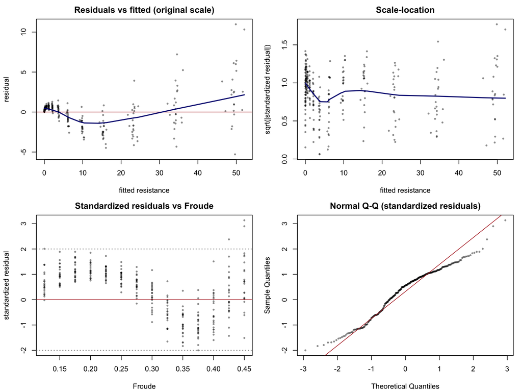

```r
op <- par(mfrow = c(2, 2), mar = c(4.2, 4.2, 2.2, 1))

## (1) residuals vs fitted
plot(fitted_M1, resid_M1, pch = 16, cex = 0.6, col = rgb(0, 0, 0, 0.45),
     xlab = "fitted resistance", ylab = "residual",
     main = "Residuals vs fitted (original scale)")
abline(h = 0, col = "firebrick"); lines(lowess(fitted_M1, resid_M1), col = "navy", lwd = 2)

## (2) scale-location: sqrt|standardized residual| vs fitted -> homoscedasticity check
plot(fitted_M1, sqrt(abs(std_M1)), pch = 16, cex = 0.6, col = rgb(0, 0, 0, 0.45),
     xlab = "fitted resistance", ylab = "sqrt(|standardized residual|)",
     main = "Scale-location")
lines(lowess(fitted_M1, sqrt(abs(std_M1))), col = "navy", lwd = 2)

## (3) standardized residuals vs the physical driver, Froude
plot(yh$Froude, std_M1, pch = 16, cex = 0.6, col = rgb(0, 0, 0, 0.45),
     xlab = "Froude", ylab = "standardized residual",
     main = "Standardized residuals vs Froude")
abline(h = c(-2, 0, 2), col = c("grey50", "firebrick", "grey50"), lty = c(3, 1, 3))

## (4) normal Q-Q of the standardized residuals
qqnorm(std_M1, pch = 16, cex = 0.6, col = rgb(0, 0, 0, 0.45),
       main = "Normal Q-Q (standardized residuals)")
qqline(std_M1, col = "firebrick")
```

```r
par(op)
save_current_pdf("task3-resid-diag.pdf", width = 10, height = 7.5)
```